# Counter Projection - Additional Analyses

```r
ggpreview(width = 8, height = 6, units = "in")
```

Interesting! With individualizing morals, people counter project more in the political condition when they are average identified than in the overall model and people strongly counter project in both the political and racial disadvantage conditions when highly identified. The overall model did not show counter projection in the racial disadvantage condition when people were highly identified.

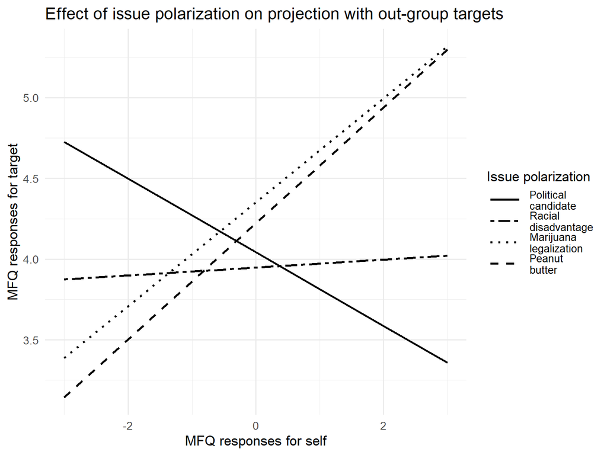

```r
knitr::opts_chunk$set(fig.width = 8, fig.height = 6)

ggplot(f1_indiv_sum_cond, aes(x = MFQSelf_c,
                              y = lsmean,
                              group = as.factor(Condition)))+
  geom_line(size = 1, aes(linetype = Condition)) +
  xlab("MFQ responses for self") +
  ylab("MFQ responses for target") +
  scale_linetype_manual("Issue polarization",
                      breaks = c(1,2,3,4),
                      labels = c("Political\ncandidate",
                                  "Racial\ndisadvantage",
                                  "Marijuana\nlegalization",
                                  "Peanut\nbutter"),
                       values = c("solid",
                                   "twodash",
                                   "dotted",
                                   "dashed")) +
  ggtitle("Effect of issue polarization on projection with out-group targets") +
  theme_minimal(base_size = 13) +
  theme(legend.text = element_text(size = 10),
        legend.key.width = unit(1.2, "cm"))
```

```r
ggpreview(width = 8, height = 6, units = "in")
```

Only difference is now there is counter projection in the political candidate condition and the racial disadvantage condition is pretty flat.

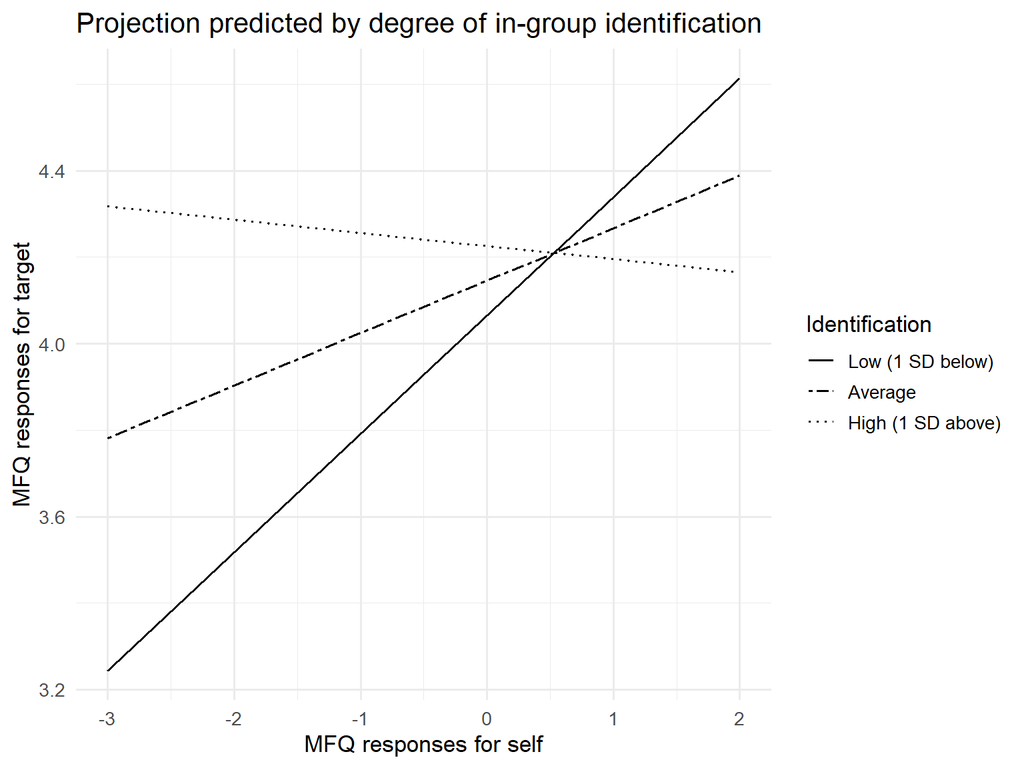

```r
knitr::opts_chunk$set(fig.width = 8, fig.height = 6)

ggplot(f1_indiv_ident, aes(MFQSelf_c,
                               fit,
                               group = Identification)) +
  geom_line(aes(linetype = Identification), size = .7) +
  scale_linetype_manual("Identification",
                       breaks = c(-1.19, 0, 1.19),
                       labels = c ("Low (1 SD below)",
                                  "Average ",
                                  "High (1 SD above)"),
                        values = c("solid",
                                   "twodash",
                                   "dotted")) +
  theme_minimal(base_size = 13) +
  labs(title = "Projection predicted by degree of in-group identification",
       x = "MFQ responses for self",
       y = "MFQ responses for target")
```

```r
ggpreview(width = 8, height = 6, units = "in")
```

Pretty similar to the original.

# BFI sub sreas: Follow-up 2

Did this previously in another document, which I have uploaded to this project.

# Political ideology breakdown of counter projection

## Initial Study - already did this above with who they voted for

## Follow-up 1

Look at whether or not they agreed or disagreed with the issue AND if the issue is generally liberal or conservative.

Condition: What issue participants were given; 1 = political candidate, 2 = racial discrimination, 3 = weed, 4 = PB

Issue_agreement: 1 for condition 1 is Clinton, 2 is Trump, for other three conditions 1 is yes to agreeing with issue, 4 is no to agreeing with issue (AKA ignoring PB, 1 = liberal, 4 = conservative beliefs)

```r
f1_ideology_model <- lmer(MFQTarg ~ MFQSelf_c*Identification_c*Condition*Issue_agreement +
                              (MFQSelf_c|Subject),
                            data = pptnpf1_comb, na.action = na.omit)

tab_model(f1_ideology_model,
          title = "Projection predicted by ideology")
```

Projection predicted by ideology

|  | MFQ Targ |  |  |
| --- | --- | --- | --- |
| Predictors | Estimates | CI | p |
| (Intercept) | 4.39 | 4.23 – 4.55 | **<0.001** |
| MFQSelf_c | 0.01 | -0.08 – 0.11 | 0.764 |
| Identification_c | 0.30 | 0.15 – 0.44 | **<0.001** |
| ConditionPRWvPB | -0.06 | -0.17 – 0.06 | 0.325 |
| ConditionPRvW | 0.26 | 0.14 – 0.39 | **<0.001** |
| ConditionPvR | -0.10 | -0.33 – 0.13 | 0.417 |
| Issue_agreement | -0.13 | -0.22 – -0.05 | **0.003** |
| MFQSelf_c * Identification_c | -0.14 | -0.23 – -0.05 | **0.002** |
| MFQSelf_c : ConditionPRWvPB | 0.16 | 0.09 – 0.23 | **<0.001** |
| MFQSelf_c : ConditionPRvW | 0.13 | 0.06 – 0.21 | **0.001** |
| MFQSelf_c : ConditionPvR | 0.29 | 0.15 – 0.43 | **<0.001** |
| Identification_c : ConditionPRWvPB | -0.14 | -0.23 – -0.05 | **0.002** |
| Identification_c : ConditionPRvW | -0.12 | -0.23 – -0.01 | **0.038** |
| Identification_c : ConditionPvR | 0.13 | -0.09 – 0.34 | 0.247 |
| MFQSelf_c * Issue_agreement | 0.07 | 0.01 – 0.12 | **0.016** |
| Identification_c * Issue_agreement | -0.15 | -0.22 – -0.07 | **<0.001** |
| ConditionPRWvPB * Issue_agreement | 0.05 | 0.01 – 0.10 | **0.015** |
| ConditionPRvW * Issue_agreement | -0.10 | -0.18 – -0.03 | **0.006** |
| ConditionPvR * Issue_agreement | 0.04 | -0.07 – 0.15 | 0.506 |
| MFQSelf_c : Identification_c : ConditionPRWvPB | 0.04 | -0.01 – 0.09 | 0.098 |
| MFQSelf_c : Identification_c : ConditionPRvW | 0.08 | 0.01 – 0.15 | **0.025** |
| MFQSelf_c : Identification_c : ConditionPvR | -0.00 | -0.14 – 0.13 | 0.943 |
| (MFQSelf_c *Identification_c)* Issue_agreement | 0.03 | -0.02 – 0.08 | 0.187 |
| (MFQSelf_c *ConditionPRWvPB)* Issue_agreement | -0.04 | -0.07 – -0.01 | **0.002** |
| (MFQSelf_c *ConditionPRvW)* Issue_agreement | 0.00 | -0.04 – 0.05 | 0.855 |
| (MFQSelf_c *ConditionPvR)* Issue_agreement | -0.06 | -0.13 – 0.02 | 0.139 |
| (Identification_c *ConditionPRWvPB)* Issue_agreement | 0.07 | 0.03 – 0.10 | **<0.001** |
| (Identification_c *ConditionPRvW)* Issue_agreement | 0.04 | -0.02 – 0.10 | 0.217 |
| (Identification_c *ConditionPvR)* Issue_agreement | 0.09 | -0.01 – 0.20 | 0.086 |
| (MFQSelf_c *Identification_c* ConditionPRWvPB) * Issue_agreement | -0.01 | -0.03 – 0.01 | 0.336 |
| (MFQSelf_c *Identification_c* ConditionPRvW) * Issue_agreement | -0.01 | -0.05 – 0.03 | 0.580 |
| (MFQSelf_c *Identification_c* ConditionPvR) * Issue_agreement | 0.02 | -0.05 – 0.08 | 0.626 |
| Random Effects |  |  |  |
| σ<sup>2</sup> | 1.32 |  |  |
| τ<sub>00</sub> <sub>Subject</sub> | 0.38 |  |  |
| τ<sub>11</sub> <sub>Subject.MFQSelf_c</sub> | 0.12 |  |  |
| ρ<sub>01</sub> <sub>Subject</sub> | 0.04 |  |  |
| ICC | 0.33 |  |  |
| N <sub>Subject</sub> | 306 |  |  |
| Observations | 6115 |  |  |
| Marginal R<sup>2</sup> / Conditional R<sup>2</sup> | 0.132 / 0.423 |  |  |

```r
describe(pptnpf1_comb$Identification_c)
```

```
##    vars    n  mean   sd median trimmed  mad   min  max range  skew kurtosis
## X1    1 6115 -0.01 1.19  -0.03       0 1.48 -2.03 1.97     4 -0.22    -0.72
##      se
## X1 0.02
```

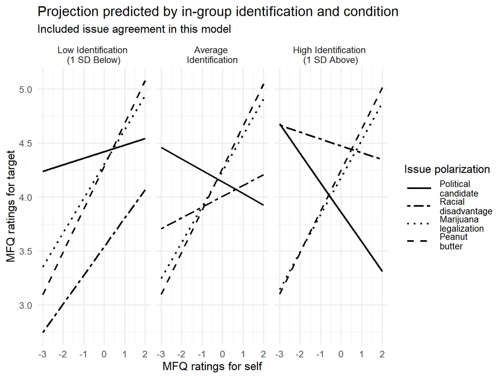

```r
effects_polident_f1 <- effect(term="MFQSelf_c:Identification_c:Condition",
                        xlevels= list(Identification_c=c(-1.19, 0, 1.19),
                                      Condition=c("1",
                                                  "2",
                                                  "3",
                                                  "4")),
                        mod=f1_ideology_model)

effects_polident_f1 <- as.data.frame(effects_polident_f1)

effects_polident_f1$Identification<-as.factor(effects_polident_f1$Identification_c)

f1_polident_ident_label <- c("-1.19"="Low Identification \n(1 SD Below)",
                       "0" = "Average \nIdentification",
                       "1.19"="High Identification \n(1 SD Above)")

ggplot(effects_polident_f1, aes(MFQSelf_c, fit)) +
  geom_line(size = 1, aes(linetype = Condition)) +
  facet_wrap(~Identification,
             labeller = labeller(Identification=f1_polident_ident_label)) +
  scale_linetype_manual("Issue polarization",
                        breaks = c(1,2,3,4),
                        labels = c ("Political\ncandidate",
                                   "Racial\ndisadvantage",
                                   "Marijuana\nlegalization",
                                   "Peanut\nbutter"),
                        values = c("solid",
                                   "twodash",
                                   "dotted",
                                   "dashed")) +
    theme_minimal(base_size = 13) +
  theme(legend.text = element_text(size = 10),
        legend.key.width = unit(1.2, "cm")) +
  labs(title = "Projection predicted by in-group identification and condition",
       subtitle = "Included issue agreement in this model",
       x = "MFQ ratings for self",
       y = "MFQ ratings for target")
```

```r
describe(pptnpf1_comb$Issue_agreement)
```

```
##    vars    n mean   sd median trimmed mad min max range skew kurtosis   se
## X1    1 6115 1.84 1.35      1    1.67   0   1   4     3 0.99    -1.03 0.02
```

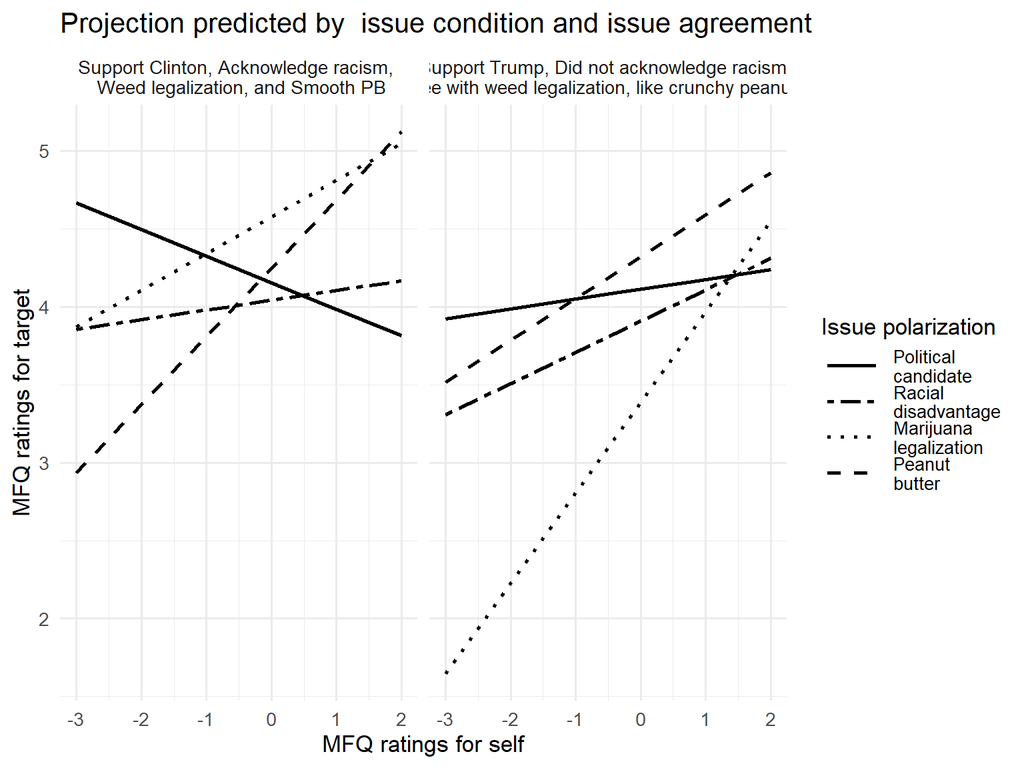

```r
effects_polident_f1_plot2 <- effect(term="MFQSelf_c:Condition:Issue_agreement",
                        xlevels= list(Issue_agreement=c(1, 4),
                                      Condition=c("1",
                                                  "2",
                                                  "3",
                                                  "4")),
                        mod=f1_ideology_model)

effects_polident_f1_plot2 <- as.data.frame(effects_polident_f1_plot2)

effects_polident_f1_plot2$Agreement<-as.factor(effects_polident_f1_plot2$Issue_agreement)

f1_polident_ident_label2 <- c("1" = "Support Clinton, Acknowledge racism, \n Weed legalization, and Smooth PB",
                             "4" = "Support Trump, Did not acknowledge racism, \n disagree with weed legalization, like crunchy peanut butter")

ggplot(effects_polident_f1_plot2, aes(MFQSelf_c, fit)) +
  geom_line(size = 1, aes(linetype = Condition)) +
  facet_wrap(~Agreement,
             labeller = labeller(Agreement=f1_polident_ident_label2)) +
  scale_linetype_manual("Issue polarization",
                        breaks = c(1,2,3,4),
                        labels = c ("Political\ncandidate",
                                   "Racial\ndisadvantage",
                                   "Marijuana\nlegalization",
                                   "Peanut\nbutter"),
                        values = c("solid",
                                   "twodash",
                                   "dotted",
                                   "dashed")) +
    theme_minimal(base_size = 13) +
  theme(legend.text = element_text(size = 10),
        legend.key.width = unit(1.2, "cm")) +
  labs(title = "Projection predicted by  issue condition and issue agreement",
       x = "MFQ ratings for self",
       y = "MFQ ratings for target")
```

## Follow-up 2

- **opin** : Whether participants agreed or disgareed with the issue they were presented (e.g., Do you support marijuana legalization?)
  - 1 = Yes
  - 4 = No

```r
contrasts(npf2_clean$condition) <- "contr.helmert"

f2_ideology_model <- lmer(targ ~ self_c*ident_c*condition*opin +
                              (self_c|sub_id),
                            data = npf2_clean, na.action = na.omit)

tab_model(f2_ideology_model,
          title = "Projection predicted by ideology")
```

Projection predicted by ideology

|  | targ |  |  |
| --- | --- | --- | --- |
| Predictors | Estimates | CI | p |
| (Intercept) | 3.14 | 3.07 – 3.21 | **<0.001** |
| self_c | 0.03 | -0.03 – 0.09 | 0.280 |
| ident_c | -0.07 | -0.15 – 0.00 | 0.061 |
| condition1 | 0.02 | -0.08 – 0.12 | 0.728 |
| condition2 | 0.09 | 0.04 – 0.15 | **0.001** |
| condition3 | -0.00 | -0.04 – 0.03 | 0.849 |
| opin | 0.03 | -0.00 – 0.07 | 0.060 |
| self_c * ident_c | -0.11 | -0.19 – -0.04 | **0.001** |
| self_c : condition1 | -0.05 | -0.13 – 0.04 | 0.308 |
| self_c : condition2 | 0.04 | -0.01 – 0.09 | 0.161 |
| self_c : condition3 | -0.01 | -0.04 – 0.02 | 0.575 |
| ident_c : condition1 | -0.01 | -0.13 – 0.11 | 0.882 |
| ident_c : condition2 | 0.06 | -0.00 – 0.12 | 0.064 |
| ident_c : condition3 | 0.01 | -0.03 – 0.06 | 0.481 |
| self_c * opin | -0.01 | -0.05 – 0.02 | 0.387 |
| ident_c * opin | -0.00 | -0.05 – 0.04 | 0.912 |
| condition1 * opin | 0.01 | -0.04 – 0.05 | 0.827 |
| condition2 * opin | -0.02 | -0.05 – 0.01 | 0.210 |
| condition3 * opin | -0.00 | -0.02 – 0.02 | 0.684 |
| self_c : ident_c : condition1 | 0.08 | -0.03 – 0.19 | 0.144 |
| self_c : ident_c : condition2 | 0.05 | -0.01 – 0.11 | 0.110 |
| self_c : ident_c : condition3 | 0.01 | -0.03 – 0.05 | 0.545 |
| (self_c * ident_c) * opin | 0.04 | -0.01 – 0.08 | 0.089 |
| (self_c * condition1) * opin | 0.01 | -0.03 – 0.05 | 0.663 |
| (self_c * condition2) * opin | -0.00 | -0.03 – 0.03 | 0.881 |
| (self_c * condition3) * opin | 0.01 | -0.01 – 0.03 | 0.228 |
| (ident_c * condition1) * opin | -0.00 | -0.07 – 0.07 | 0.960 |
| (ident_c * condition2) * opin | -0.04 | -0.08 – -0.00 | **0.032** |
| (ident_c * condition3) * opin | 0.00 | -0.02 – 0.02 | 0.994 |
| (self_c * ident_c *condition1)* opin | -0.03 | -0.09 – 0.02 | 0.254 |
| (self_c * ident_c *condition2)* opin | -0.04 | -0.08 – 0.00 | 0.062 |
| (self_c * ident_c *condition3)* opin | -0.00 | -0.02 – 0.02 | 0.808 |
| Random Effects |  |  |  |
| σ<sup>2</sup> | 1.03 |  |  |
| τ<sub>00</sub> <sub>sub_id</sub> | 0.05 |  |  |
| τ<sub>11</sub> <sub>sub_id.self_c</sub> | 0.04 |  |  |
| ρ<sub>01</sub> <sub>sub_id</sub> | 0.53 |  |  |
| ICC | 0.10 |  |  |
| N <sub>sub_id</sub> | 334 |  |  |
| Observations | 6324 |  |  |
| Marginal R<sup>2</sup> / Conditional R<sup>2</sup> | 0.025 / 0.125 |  |  |

Model failed to converge, so results are unreliable. Any plot using intercepts and slopes from this model would also be unreliable.

# Demographic differences in counter projection

## Initial Study - Race

```r
dem_analysis <- clean_data2 %>%
  select(subid, MFQ_Number, MFQSelf_c, MFQStereo_c, MFQTarg, ident_c, PT_effects,
         inoutgroup_effects, par_cand, Race) %>%
  unique() %>%
  na.omit()

projmodel_stereo_race <- lmer(MFQTarg ~ MFQSelf_c * MFQStereo_c *
                                    inoutgroup_effects * ident_c * Race +
                                    (MFQSelf_c|subid),
                                 data = dem_analysis)

tab_model(projmodel_stereo_race,
          title = "Projection moderated by stereotyping and race")
```

Projection moderated by stereotyping and race

|  | MFQ Targ |  |  |
| --- | --- | --- | --- |
| Predictors | Estimates | CI | p |
| (Intercept) | 3.25 | 2.39 – 4.11 | **<0.001** |
| MFQSelf_c | 0.60 | 0.18 – 1.02 | **0.005** |
| MFQStereo_c | -0.47 | -0.72 – -0.21 | **<0.001** |
| inoutgroup_effects | 1.52 | -0.12 – 3.15 | 0.069 |
| ident_c | 0.04 | -0.50 – 0.59 | 0.883 |
| Race [Asian] | 0.79 | -0.10 – 1.68 | 0.083 |
| Race [Black] | 0.96 | 0.07 – 1.85 | **0.034** |
| Race [Latinx] | 1.12 | 0.23 – 2.02 | **0.014** |
| Race [Middle Eastern] | -0.21 | -2.10 – 1.68 | 0.826 |
| Race [Caucasian] | 0.95 | 0.09 – 1.81 | **0.031** |
| Race [Multiracial] | 1.19 | 0.28 – 2.11 | **0.010** |
| Race [Other] | 0.70 | -0.64 – 2.04 | 0.309 |
| MFQSelf_c * MFQStereo_c | 0.08 | -0.03 – 0.20 | 0.154 |
| MFQSelf_c * inoutgroup_effects | 0.20 | -0.61 – 1.00 | 0.629 |
| MFQStereo_c * inoutgroup_effects | 1.10 | 0.58 – 1.62 | **<0.001** |
| MFQSelf_c * ident_c | -0.15 | -0.45 – 0.14 | 0.300 |
| MFQStereo_c * ident_c | 0.09 | -0.16 – 0.33 | 0.489 |
| inoutgroup_effects * ident_c | 0.32 | -0.02 – 0.66 | 0.064 |
| MFQSelf_c * Race [Asian] | -0.53 | -0.97 – -0.10 | **0.016** |
| MFQSelf_c * Race [Black] | -0.48 | -0.91 – -0.05 | **0.030** |
| MFQSelf_c * Race [Latinx] | -0.44 | -0.87 – -0.00 | **0.048** |
| MFQSelf_c * Race [Middle Eastern] | -1.02 | -2.20 – 0.17 | 0.093 |
| MFQSelf_c * Race [Caucasian] | -0.45 | -0.87 – -0.03 | **0.034** |
| MFQSelf_c * Race [Multiracial] | -0.52 | -0.96 – -0.07 | **0.023** |
| MFQSelf_c * Race [Other] | -0.36 | -1.09 – 0.37 | 0.334 |
| MFQStereo_c * Race [Asian] | 0.63 | 0.36 – 0.89 | **<0.001** |
| MFQStereo_c * Race [Black] | 0.54 | 0.28 – 0.80 | **<0.001** |
| MFQStereo_c * Race [Latinx] | 0.50 | 0.23 – 0.76 | **<0.001** |
| MFQStereo_c * Race [Middle Eastern] | 0.12 | -0.74 – 0.97 | 0.790 |

[output cut: 84 more lines]

Model is rank deficient, not enough power to check if results differ by race. Could possibly do white vs minorities, but that doesn’t feel telling enough.

## Initial Study - Gender

```r
gender_analysis <- clean_data2 %>%
  select(subid, MFQ_Number, MFQSelf_c, MFQStereo_c, MFQTarg, ident_c, PT_effects,
         inoutgroup_effects, par_cand, Gender) %>%
  unique() %>%
  na.omit()

projmodel_stereo_gender <- lmer(MFQTarg ~ MFQSelf_c * MFQStereo_c *
                                    inoutgroup_effects * ident_c * Gender +
                                    (MFQSelf_c|subid),
                                 data = gender_analysis)

tab_model(projmodel_stereo_gender,
          title = "Projection moderated by stereotyping and gender")
```

Projection moderated by stereotyping and gender

|  | MFQ Targ |  |  |
| --- | --- | --- | --- |
| Predictors | Estimates | CI | p |
| (Intercept) | 4.03 | 3.94 – 4.12 | **<0.001** |
| MFQSelf_c | 0.14 | 0.09 – 0.19 | **<0.001** |
| MFQStereo_c | 0.04 | 0.01 – 0.07 | **0.003** |
| inoutgroup_effects | 0.30 | 0.11 – 0.48 | **0.002** |
| ident_c | 0.03 | -0.03 – 0.08 | 0.322 |
| Gender [Female] | 0.25 | 0.14 – 0.37 | **<0.001** |
| Gender [Other] | 0.14 | -0.91 – 1.19 | 0.792 |
| MFQSelf_c * MFQStereo_c | -0.03 | -0.04 – -0.01 | **<0.001** |
| MFQSelf_c * inoutgroup_effects | 0.35 | 0.26 – 0.44 | **<0.001** |
| MFQStereo_c * inoutgroup_effects | 0.60 | 0.55 – 0.65 | **<0.001** |
| MFQSelf_c * ident_c | 0.00 | -0.02 – 0.03 | 0.727 |
| MFQStereo_c * ident_c | -0.05 | -0.07 – -0.04 | **<0.001** |
| inoutgroup_effects * ident_c | 0.30 | 0.19 – 0.40 | **<0.001** |
| MFQSelf_c * Gender [Female] | -0.00 | -0.06 – 0.05 | 0.954 |
| MFQSelf_c * Gender [Other] | 0.08 | -0.41 – 0.57 | 0.756 |
| MFQStereo_c * Gender [Female] | 0.05 | 0.02 – 0.09 | **0.002** |
| MFQStereo_c * Gender [Other] | 0.04 | -0.31 – 0.40 | 0.824 |
| inoutgroup_effects * Gender [Female] | -0.10 | -0.32 – 0.13 | 0.407 |
| inoutgroup_effects * Gender [Other] | 0.43 | -1.67 – 2.53 | 0.689 |
| ident_c * Gender [Female] | 0.02 | -0.04 – 0.09 | 0.493 |
| ident_c * Gender [Other] | -0.15 | -0.56 – 0.25 | 0.452 |
| (MFQSelf_c * MFQStereo_c) * inoutgroup_effects | 0.02 | -0.01 – 0.05 | 0.190 |
| (MFQSelf_c * MFQStereo_c) * ident_c | -0.01 | -0.01 – 0.00 | 0.153 |
| (MFQSelf_c *inoutgroup_effects)* ident_c | 0.03 | -0.02 – 0.08 | 0.253 |
| (MFQStereo_c *inoutgroup_effects)* ident_c | 0.02 | -0.01 – 0.05 | 0.202 |
| (MFQSelf_c * MFQStereo_c) * Gender [Female] | 0.00 | -0.02 – 0.02 | 0.964 |
| (MFQSelf_c * MFQStereo_c) * Gender [Other] | 0.00 | -0.17 – 0.17 | 0.995 |
| (MFQSelf_c *inoutgroup_effects)* Gender [Female] | 0.04 | -0.08 – 0.15 | 0.536 |
| (MFQSelf_c *inoutgroup_effects)* Gender [Other] | -0.45 | -1.43 – 0.53 | 0.366 |
| (MFQStereo_c *inoutgroup_effects)* Gender [Female] | -0.00 | -0.07 – 0.06 | 0.949 |
| (MFQStereo_c *inoutgroup_effects)* Gender [Other] | -0.23 | -0.94 – 0.48 | 0.530 |
| (MFQSelf_c * ident_c) * Gender [Female] | 0.00 | -0.03 – 0.03 | 0.914 |
| (MFQSelf_c * ident_c) * Gender [Other] | -0.01 | -0.19 – 0.18 | 0.953 |
| (MFQStereo_c * ident_c) * Gender [Female] | 0.03 | 0.01 – 0.05 | **0.001** |
| (MFQStereo_c * ident_c) * Gender [Other] | 0.04 | -0.14 – 0.22 | 0.650 |
| (inoutgroup_effects *ident_c)* Gender [Female] | -0.09 | -0.22 – 0.04 | 0.163 |
| (inoutgroup_effects *ident_c)* Gender [Other] | 0.12 | -0.68 – 0.93 | 0.768 |
| (MFQSelf_c * MFQStereo_c * inoutgroup_effects) * ident_c | -0.01 | -0.03 – 0.00 | 0.138 |
| (MFQSelf_c * MFQStereo_c * inoutgroup_effects) * Gender [Female] | -0.01 | -0.05 – 0.02 | 0.518 |
| (MFQSelf_c * MFQStereo_c * inoutgroup_effects) * Gender [Other] | -0.27 | -0.61 – 0.08 | 0.127 |
| (MFQSelf_c * MFQStereo_c * ident_c) * Gender [Female] | -0.00 | -0.01 – 0.01 | 0.766 |
| (MFQSelf_c * MFQStereo_c * ident_c) * Gender [Other] | 0.01 | -0.08 – 0.09 | 0.900 |
| (MFQSelf_c *inoutgroup_effects* ident_c) * Gender [Female] | -0.03 | -0.10 – 0.03 | 0.282 |
| (MFQSelf_c *inoutgroup_effects* ident_c) * Gender [Other] | -0.29 | -0.66 – 0.09 | 0.132 |
| (MFQStereo_c *inoutgroup_effects* ident_c) * Gender [Female] | -0.02 | -0.06 – 0.02 | 0.261 |
| (MFQStereo_c *inoutgroup_effects* ident_c) * Gender [Other] | 0.22 | -0.13 – 0.58 | 0.218 |
| (MFQSelf_c * MFQStereo_c * inoutgroup_effects *ident_c)* Gender [Female] | 0.02 | -0.00 – 0.04 | 0.065 |
| (MFQSelf_c * MFQStereo_c * inoutgroup_effects *ident_c)* Gender [Other] | -0.03 | -0.20 – 0.14 | 0.754 |
| Random Effects |  |  |  |
| σ<sup>2</sup> | 1.31 |  |  |
| τ<sub>00</sub> <sub>subid</sub> | 0.44 |  |  |
| τ<sub>11</sub> <sub>subid.MFQSelf_c</sub> | 0.08 |  |  |
| ρ<sub>01</sub> <sub>subid</sub> | -0.04 |  |  |
| ICC | 0.32 |  |  |
| N <sub>subid</sub> | 673 |  |  |
| Observations | 20015 |  |  |
| Marginal R<sup>2</sup> / Conditional R<sup>2</sup> | 0.223 / 0.473 |  |  |

## Follow-up 1 - Gender

```r
f1_gender <- lmer(MFQTarg ~ MFQSelf_c*Identification_c*Condition*Gender +
                              (MFQSelf_c|Subject),
                            data = pptnpf1_comb, na.action = na.omit)
```

When adding gender,the model failed to converge.

## Follow-up 1 - Race

```r
f1_race <- lmer(MFQTarg ~ MFQSelf_c*Identification_c*Condition*Race +
                              (MFQSelf_c|Subject),
                            data = pptnpf1_comb, na.action = na.omit)
```

When adding race, the fixed effect model was rank deficient and dropped predictors/comparisons.

## Follow-up 2 - Gender

```r
npf2_clean <- npf2_clean %>%
  mutate(gender = as.factor(gender),
         race = as.factor(race))

f2_gender <- lmer(targ ~ self_c*ident_c*condition*gender +
                              (self_c|sub_id),
                            data = npf2_clean, na.action = na.omit)
```

Fixed effect model is rank deficient

## Follow-up 2 - Race

```r
f2_race <- lmer(targ ~ self_c*ident_c*condition*race +
                              (self_c|sub_id),
                            data = npf2_clean, na.action = na.omit)
```

Fixed effect model is rank deficient. We don’t have enough power to include extra categorical variables…

# Downstream outcomes impacted by counter projection - Initial Study

```r
downstream_analysis <- clean_data2 %>%
  select(subid, MFQ_Number, MFQSelf, MFQSelf_c, MFQStereo_c, MFQTarg, ident_c,
         inoutgroup_effects, par_cand, Liking, WilltoDiscuss, Contentious, Treatment, Valid, MFQStereo) %>%
  unique() %>%
  na.omit() %>%
  group_by(subid) %>%
  #getting the difference scores
  #decided to not mean center difference scores, since 0 is meaningful (no difference = 100% projection)
  mutate(proj_diff = abs(mean(MFQTarg) - mean(MFQSelf)),
         stereo_diff = abs(mean(MFQTarg)- mean(MFQStereo)))

mfq_binding_diff <- mfq_binding %>%
  group_by(subid) %>%
  mutate(proj_bind_diff = abs(mean(MFQTarg) - mean(MFQSelf)),
         stereo_bind_diff = abs(mean(MFQTarg) - mean(MFQStereo)))

mfq_individual_diff <- mfq_individual %>%
 group_by(subid) %>%
  mutate(proj_indiv_diff = abs(mean(MFQTarg) - mean(MFQStereo)),
         stereo_indiv_diff = abs(mean(MFQTarg) - mean(MFQStereo))) %>%
  na.omit()
```

## How much do you like the target?

### Overall model

```r
liking_overall <- lm(Liking ~ proj_diff*stereo_diff*inoutgroup_effects*ident_c, downstream_analysis)
summary(liking_overall)
```

```
##
## Call:
## lm(formula = Liking ~ proj_diff * stereo_diff * inoutgroup_effects *
##     ident_c, data = downstream_analysis)
##
## Residuals:
##     Min      1Q  Median      3Q     Max
## -3.4540 -0.8020  0.2304  0.7574  4.0435
##
## Coefficients:
##                                                   Estimate Std. Error t value
## (Intercept)                                       4.719954   0.021130 223.377
## proj_diff                                        -0.190032   0.034956  -5.436
## stereo_diff                                      -0.165177   0.035573  -4.643
## inoutgroup_effects                                1.663988   0.042260  39.375
## ident_c                                           0.153919   0.011369  13.539
## proj_diff:stereo_diff                             0.077122   0.045368   1.700
## proj_diff:inoutgroup_effects                     -0.123782   0.069911  -1.771
## stereo_diff:inoutgroup_effects                    0.630144   0.071146   8.857
## proj_diff:ident_c                                -0.111098   0.015032  -7.391
## stereo_diff:ident_c                               0.106644   0.018233   5.849
## inoutgroup_effects:ident_c                        0.230630   0.022737  10.143
## proj_diff:stereo_diff:inoutgroup_effects         -0.105041   0.090736  -1.158
## proj_diff:stereo_diff:ident_c                    -0.017069   0.014762  -1.156
## proj_diff:inoutgroup_effects:ident_c             -0.021255   0.030064  -0.707
## stereo_diff:inoutgroup_effects:ident_c            0.165531   0.036467   4.539
## proj_diff:stereo_diff:inoutgroup_effects:ident_c  0.003271   0.029524   0.111
##                                                              Pr(>|t|)
## (Intercept)                                      < 0.0000000000000002 ***
## proj_diff                                           0.000000055011895 ***
## stereo_diff                                         0.000003450972714 ***
## inoutgroup_effects                               < 0.0000000000000002 ***
## ident_c                                          < 0.0000000000000002 ***
## proj_diff:stereo_diff                                          0.0892 .
## proj_diff:inoutgroup_effects                                   0.0766 .
## stereo_diff:inoutgroup_effects                   < 0.0000000000000002 ***
## proj_diff:ident_c                                   0.000000000000152 ***
## stereo_diff:ident_c                                 0.000000005027905 ***
## inoutgroup_effects:ident_c                       < 0.0000000000000002 ***
## proj_diff:stereo_diff:inoutgroup_effects                       0.2470
## proj_diff:stereo_diff:ident_c                                  0.2476
## proj_diff:inoutgroup_effects:ident_c                           0.4796
## stereo_diff:inoutgroup_effects:ident_c              0.000005678979911 ***
## proj_diff:stereo_diff:inoutgroup_effects:ident_c               0.9118
## ---
## Signif. codes:  0 '***' 0.001 '**' 0.01 '*' 0.05 '.' 0.1 ' ' 1
##
## Residual standard error: 1.262 on 19882 degrees of freedom
## Multiple R-squared:  0.4223, Adjusted R-squared:  0.4219
## F-statistic: 969.1 on 15 and 19882 DF,  p-value: < 0.00000000000000022
```

### Overall model Plots

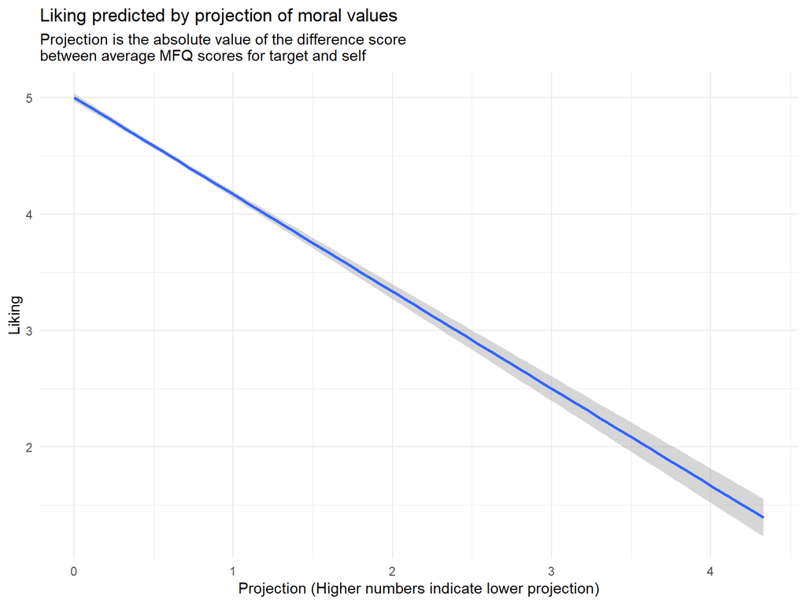

```r
#main effect of projection
ggplot(downstream_analysis, aes(proj_diff, Liking)) +
  geom_smooth(method = "lm") +
  theme_minimal() +
  labs(title = "Liking predicted by projection of moral values",
       subtitle = "Projection is the absolute value of the difference score \nbetween average MFQ scores for target and self",
       x = "Projection (Higher numbers indicate lower projection)",
       y = "Liking")
```

Counter projection can be seen as anything with a distance over 1, as that means that people are not listing their score as the same as the targets. The greater the distance demonstrates the greater the counter projection. As can be seen, as people counter project more, they report liking the target less. People who project normally report liking the target the most.

```r
#interaction between projection and degree of identification
describe(downstream_analysis$ident_c)
```

```
##    vars     n  mean   sd median trimmed mad   min  max range  skew kurtosis
## X1    1 19898 -0.03 1.78  -0.01   -0.04 1.8 -4.23 3.77     8 -0.02    -0.32
##      se
## X1 0.01
```

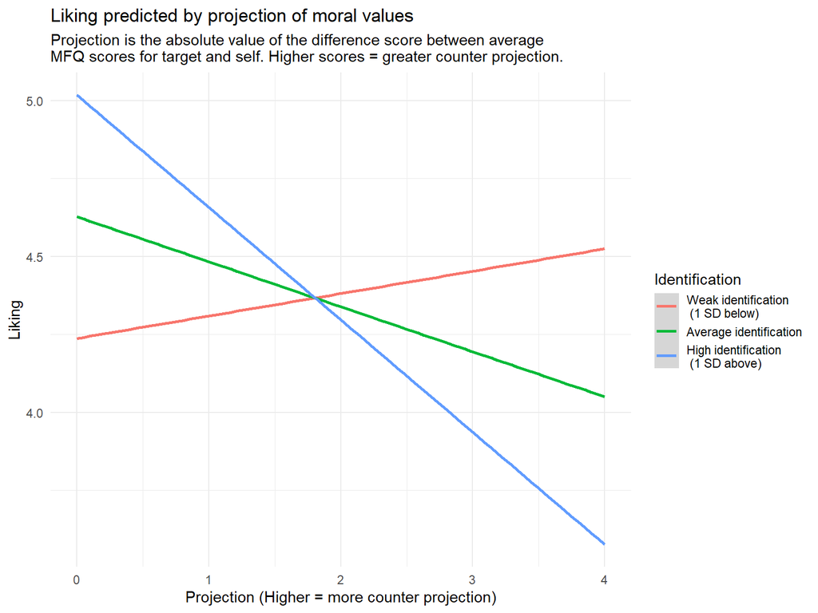

```r
liking_overall_2way <- effect(term = "proj_diff:ident_c",
                           xlevels = list(ident_c = c(-1.78, 0, 1.78)),
                           mod = liking_overall)

liking_overall_2way <- as.data.frame(liking_overall_2way)

liking_overall_2way$Identification <- as.factor(liking_overall_2way$ident_c)

ggplot(liking_overall_2way, aes(proj_diff, fit, group = Identification, color = Identification)) +
  geom_smooth(method = "lm") +
  theme_minimal() +
  scale_color_discrete("Identification", breaks = c(-1.78, 0, 1.78),
                       labels = c("Weak identification \n (1 SD below)",
                                  "Average identification",
                                  "High identification \n (1 SD above)")) +
  labs(title = "Liking predicted by projection of moral values",
       subtitle = "Projection is the absolute value of the difference score between average \nMFQ scores for target and self. Higher scores = greater counter projection.",
       x = "Projection (Higher = more counter projection)",
       y = "Liking")
```

Those who weakly identify continue to like the target, even as the distance between their scores on the MFQ and their target’s increase (becoming less similar, less projection). As in-group identification increases, self-reported liking of the target decreases as counter projection increases.

### Binding model

```r
liking_bind <- lm(Liking ~ proj_bind_diff*stereo_bind_diff*inoutgroup_effects*ident_c, mfq_binding_diff)
summary(liking_bind)
```

```
##
## Call:
## lm(formula = Liking ~ proj_bind_diff * stereo_bind_diff * inoutgroup_effects *
##     ident_c, data = mfq_binding_diff)
##
## Residuals:
##     Min      1Q  Median      3Q     Max
## -3.5388 -0.7824  0.1056  0.7848  3.5943
##
## Coefficients:
##                                                             Estimate Std. Error
## (Intercept)                                                 4.794162   0.026896
## proj_bind_diff                                             -0.090386   0.029169
## stereo_bind_diff                                            0.028208   0.030557
## inoutgroup_effects                                          1.464714   0.053792
## ident_c                                                     0.089831   0.016064
## proj_bind_diff:stereo_bind_diff                            -0.044362   0.026371
## proj_bind_diff:inoutgroup_effects                           0.139702   0.058339
## stereo_bind_diff:inoutgroup_effects                        -0.042776   0.061114
## proj_bind_diff:ident_c                                     -0.004495   0.013961
## stereo_bind_diff:ident_c                                    0.115828   0.017389
## inoutgroup_effects:ident_c                                  0.190607   0.032128
## proj_bind_diff:stereo_bind_diff:inoutgroup_effects          0.112589   0.052742
## proj_bind_diff:stereo_bind_diff:ident_c                    -0.038439   0.011566
## proj_bind_diff:inoutgroup_effects:ident_c                   0.124375   0.027921
## stereo_bind_diff:inoutgroup_effects:ident_c                 0.129997   0.034779
## proj_bind_diff:stereo_bind_diff:inoutgroup_effects:ident_c -0.064567   0.023133
##                                                            t value
## (Intercept)                                                178.249
## proj_bind_diff                                              -3.099
## stereo_bind_diff                                             0.923
## inoutgroup_effects                                          27.229
## ident_c                                                      5.592
## proj_bind_diff:stereo_bind_diff                             -1.682
## proj_bind_diff:inoutgroup_effects                            2.395
## stereo_bind_diff:inoutgroup_effects                         -0.700
## proj_bind_diff:ident_c                                      -0.322
## stereo_bind_diff:ident_c                                     6.661
## inoutgroup_effects:ident_c                                   5.933
## proj_bind_diff:stereo_bind_diff:inoutgroup_effects           2.135
```

[output cut: 29 more lines]

```
## stereo_bind_diff:inoutgroup_effects
## proj_bind_diff:ident_c
## stereo_bind_diff:ident_c                                   ***
## inoutgroup_effects:ident_c                                 ***
## proj_bind_diff:stereo_bind_diff:inoutgroup_effects         *
## proj_bind_diff:stereo_bind_diff:ident_c                    ***
## proj_bind_diff:inoutgroup_effects:ident_c                  ***
## stereo_bind_diff:inoutgroup_effects:ident_c                ***
## proj_bind_diff:stereo_bind_diff:inoutgroup_effects:ident_c **
## ---
## Signif. codes:  0 '***' 0.001 '**' 0.01 '*' 0.05 '.' 0.1 ' ' 1
##
## Residual standard error: 1.215 on 11926 degrees of freedom
## Multiple R-squared:  0.4644, Adjusted R-squared:  0.4637
## F-statistic: 689.3 on 15 and 11926 DF,  p-value: < 0.00000000000000022
```

### Binding model plots

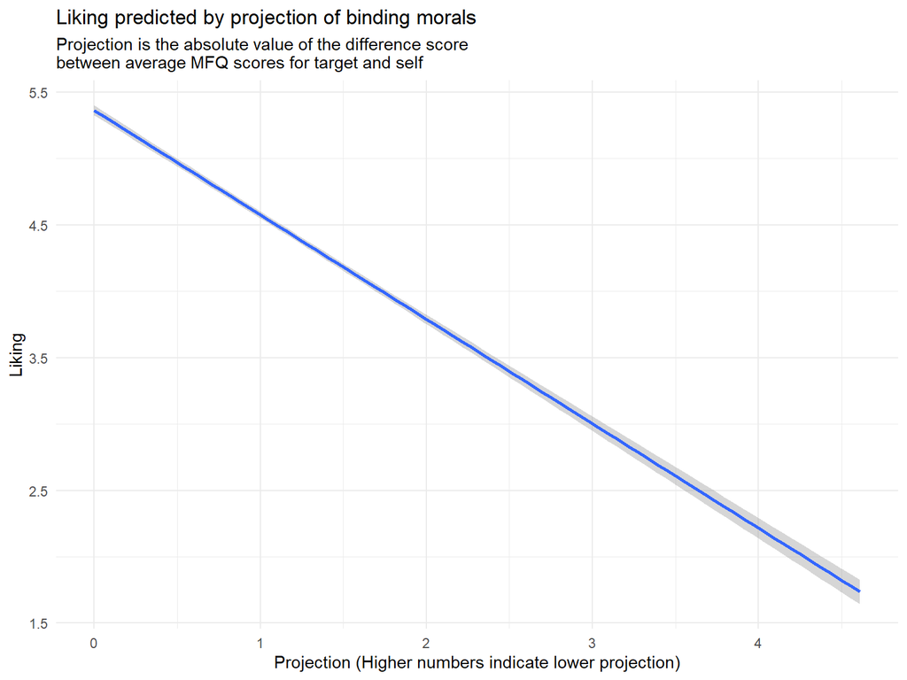

```r
#main effect of projection
ggplot(mfq_binding_diff, aes(proj_bind_diff, Liking)) +
  geom_smooth(method = "lm") +
  theme_minimal() +
  labs(title = "Liking predicted by projection of binding morals",
       subtitle = "Projection is the absolute value of the difference score \nbetween average MFQ scores for target and self",
       x = "Projection (Higher numbers indicate lower projection)",
       y = "Liking")
```

Same as overall plot.

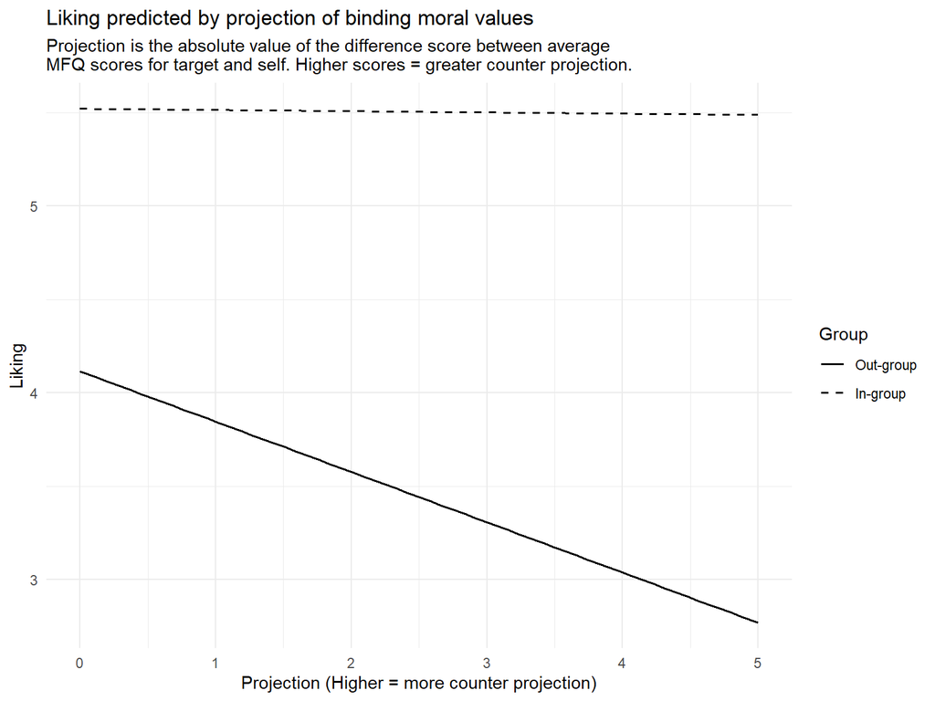

```r
liking_bind_2way_group <- effect(term = "proj_bind_diff:inoutgroup_effects",
                           xlevels = list(inoutgroup_effects = c(-.5,.5)),
                           mod = liking_bind)

liking_bind_2way_group <- as.data.frame(liking_bind_2way_group)

liking_bind_2way_group$group <- as.factor(liking_bind_2way_group$inoutgroup_effects)

ggplot(liking_bind_2way_group, aes(proj_bind_diff, fit, group = group, color = group)) +
 geom_smooth(method = "lm", se = FALSE, size = .7, colour = "black",
              aes(linetype = group)) +
  theme_minimal() +
  scale_linetype_manual("Group", breaks = c(-.5, .5),
                       labels = c("Out-group", "In-group"),
                       values = c("solid",
                                   "dashed")) +
  labs(title = "Liking predicted by projection of binding moral values",
       subtitle = "Projection is the absolute value of the difference score between average \nMFQ scores for target and self. Higher scores = greater counter projection.",
       x = "Projection (Higher = more counter projection)",
       y = "Liking")
```

Liking stays high with the in-group, regardless of their degree of projection. Liking is highest for the out-group when they are projecting. As counter projection increases (the distance becomes further), liking decreases for the out-group.

```r
describe(stereo_analysis$ident_c)
```

```
##    vars     n  mean   sd median trimmed mad   min  max range  skew kurtosis
## X1    1 20045 -0.03 1.78  -0.01   -0.04 1.8 -4.23 3.77     8 -0.02    -0.32
##      se
## X1 0.01
```

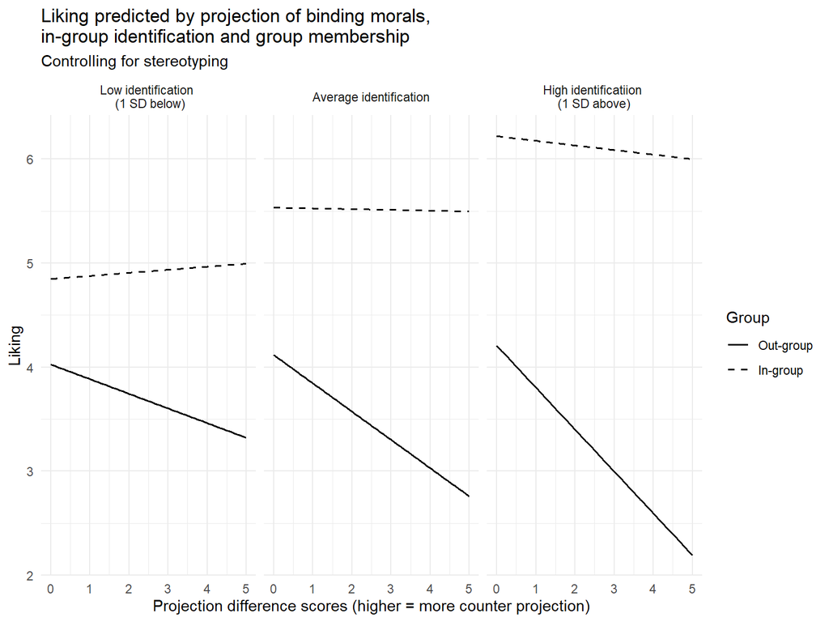

```r
binding_liking_3way <- effect(term = "proj_bind_diff:inoutgroup_effects:ident_c",
                           xlevels = list(ident_c = c(-1.78, 0, 1.78),
                                         inoutgroup_effects = c(-.5,.5)),
                           mod = liking_bind)

binding_liking_3way <- as.data.frame(binding_liking_3way)

binding_liking_3way$Group <- as.factor(binding_liking_3way$inoutgroup_effects)
binding_liking_3way$Identification <- as.factor(binding_liking_3way$ident_c)

ident_label <- c("-1.78" = "Low identification \n (1 SD below)",
                 "0" = "Average identification",
                 "1.78" = "High identificatiion \n(1 SD above)")

ggplot(binding_liking_3way, aes(proj_bind_diff,
                             fit,
                             group = Group,
                             color = Group)) +
  geom_smooth(method = "lm", se = FALSE, size = .7, colour = "black",
              aes(linetype = Group)) +
  facet_wrap(~Identification, labeller =
               labeller(Identification = ident_label)) +
  scale_linetype_manual("Group", breaks = c(-.5, .5),
                       labels = c("Out-group", "In-group"),
                       values = c("solid",
                                   "dashed")) +
  theme_minimal() +
  labs(title = "Liking predicted by projection of binding morals, \nin-group identification and group membership",
       subtitle = "Controlling for stereotyping",
       x = "Projection difference scores (higher = more counter projection)",
       y = "Liking")
```

As can be seen in the plot above, people report liking an in-group target at a similiar rate regardless of projection, while liking of the out-group target decreases as both counter projection and in-group identification increase. Thus, the people who report liking the least are considering an out-group target and are highly identified with their in-group as well as projecting their own morals the least.

### Individuating model

```r
liking_indiv <- lm(Liking ~ proj_indiv_diff*stereo_indiv_diff*inoutgroup_effects*ident_c, mfq_individual_diff)
summary(liking_indiv)
```

```
##
## Call:
## lm(formula = Liking ~ proj_indiv_diff * stereo_indiv_diff * inoutgroup_effects *
##     ident_c, data = mfq_individual_diff)
##
## Residuals:
##     Min      1Q  Median      3Q     Max
## -3.5668 -0.7639  0.1056  0.7996  3.6753
##
## Coefficients: (4 not defined because of singularities)
##                                                              Estimate
## (Intercept)                                                   4.87853
## proj_indiv_diff                                              -0.17945
## stereo_indiv_diff                                                  NA
## inoutgroup_effects                                            1.28560
## ident_c                                                       0.04418
## proj_indiv_diff:stereo_indiv_diff                            -0.08643
## proj_indiv_diff:inoutgroup_effects                            0.62506
## stereo_indiv_diff:inoutgroup_effects                               NA
## proj_indiv_diff:ident_c                                       0.25313
## stereo_indiv_diff:ident_c                                          NA
## inoutgroup_effects:ident_c                                    0.17232
## proj_indiv_diff:stereo_indiv_diff:inoutgroup_effects         -0.12613
## proj_indiv_diff:stereo_indiv_diff:ident_c                    -0.10738
## proj_indiv_diff:inoutgroup_effects:ident_c                    0.47335
## stereo_indiv_diff:inoutgroup_effects:ident_c                       NA
## proj_indiv_diff:stereo_indiv_diff:inoutgroup_effects:ident_c -0.20190
##                                                              Std. Error t value
## (Intercept)                                                     0.03012 161.976
## proj_indiv_diff                                                 0.06826  -2.629
## stereo_indiv_diff                                                    NA      NA
## inoutgroup_effects                                              0.06024  21.342
## ident_c                                                         0.01492   2.960
## proj_indiv_diff:stereo_indiv_diff                               0.03666  -2.358
## proj_indiv_diff:inoutgroup_effects                              0.13653   4.578
## stereo_indiv_diff:inoutgroup_effects                                 NA      NA
## proj_indiv_diff:ident_c                                         0.03434   7.372
## stereo_indiv_diff:ident_c                                            NA      NA
## inoutgroup_effects:ident_c                                      0.02985   5.773
## proj_indiv_diff:stereo_indiv_diff:inoutgroup_effects            0.07331  -1.720
```

[output cut: 29 more lines]

```
## stereo_indiv_diff:inoutgroup_effects
## proj_indiv_diff:ident_c                                      ***
## stereo_indiv_diff:ident_c
## inoutgroup_effects:ident_c                                   ***
## proj_indiv_diff:stereo_indiv_diff:inoutgroup_effects         .
## proj_indiv_diff:stereo_indiv_diff:ident_c                    ***
## proj_indiv_diff:inoutgroup_effects:ident_c                   ***
## stereo_indiv_diff:inoutgroup_effects:ident_c
## proj_indiv_diff:stereo_indiv_diff:inoutgroup_effects:ident_c ***
## ---
## Signif. codes:  0 '***' 0.001 '**' 0.01 '*' 0.05 '.' 0.1 ' ' 1
##
## Residual standard error: 1.206 on 7944 degrees of freedom
## Multiple R-squared:  0.4728, Adjusted R-squared:  0.4721
## F-statistic: 647.8 on 11 and 7944 DF,  p-value: < 0.00000000000000022
```

```r
linear_check <- lm(Liking ~ proj_indiv_diff*stereo_indiv_diff, mfq_individual_diff)
summary(linear_check)
```

```
##
## Call:
## lm(formula = Liking ~ proj_indiv_diff * stereo_indiv_diff, data = mfq_individual_diff)
##
## Residuals:
##     Min      1Q  Median      3Q     Max
## -4.3951 -0.9955  0.0045  1.0045  3.8465
##
## Coefficients: (1 not defined because of singularities)
##                                    Estimate Std. Error t value
## (Intercept)                        5.395091   0.031230 172.753
## proj_indiv_diff                   -0.961255   0.053442 -17.987
## stereo_indiv_diff                        NA         NA      NA
## proj_indiv_diff:stereo_indiv_diff  0.005448   0.015889   0.343
##                                              Pr(>|t|)
## (Intercept)                       <0.0000000000000002 ***
## proj_indiv_diff                   <0.0000000000000002 ***
## stereo_indiv_diff                                  NA
## proj_indiv_diff:stereo_indiv_diff               0.732
## ---
## Signif. codes:  0 '***' 0.001 '**' 0.01 '*' 0.05 '.' 0.1 ' ' 1
##
## Residual standard error: 1.439 on 7953 degrees of freedom
## Multiple R-squared:  0.2486, Adjusted R-squared:  0.2484
## F-statistic:  1315 on 2 and 7953 DF,  p-value: < 0.00000000000000022
```

## How willing would you be to have a conversation about your political views with this person?

### Overall model output

```r
discuss_overall <- lm(WilltoDiscuss ~ proj_diff*stereo_diff*inoutgroup_effects*ident_c, downstream_analysis)
summary(discuss_overall)
```

```
##
## Call:
## lm(formula = WilltoDiscuss ~ proj_diff * stereo_diff * inoutgroup_effects *
##     ident_c, data = downstream_analysis)
##
## Residuals:
##     Min      1Q  Median      3Q     Max
## -5.0428 -1.0559  0.2463  1.0248  3.3346
##
## Coefficients:
##                                                  Estimate Std. Error t value
## (Intercept)                                       5.09481    0.02811 181.226
## proj_diff                                        -0.18734    0.04651  -4.028
## stereo_diff                                      -0.33715    0.04733  -7.123
## inoutgroup_effects                                2.15681    0.05623  38.360
## ident_c                                          -0.07428    0.01513  -4.911
## proj_diff:stereo_diff                             0.17127    0.06036   2.837
## proj_diff:inoutgroup_effects                     -0.75887    0.09302  -8.159
## stereo_diff:inoutgroup_effects                   -0.62032    0.09466  -6.553
## proj_diff:ident_c                                 0.05186    0.02000   2.593
## stereo_diff:ident_c                               0.36063    0.02426  14.866
## inoutgroup_effects:ident_c                        0.22031    0.03025   7.283
## proj_diff:stereo_diff:inoutgroup_effects          0.56341    0.12072   4.667
## proj_diff:stereo_diff:ident_c                    -0.11896    0.01964  -6.057
## proj_diff:inoutgroup_effects:ident_c             -0.08602    0.04000  -2.151
## stereo_diff:inoutgroup_effects:ident_c            0.40581    0.04852   8.364
## proj_diff:stereo_diff:inoutgroup_effects:ident_c -0.14472    0.03928  -3.684
##                                                              Pr(>|t|)
## (Intercept)                                      < 0.0000000000000002 ***
## proj_diff                                        0.000056402922172085 ***
## stereo_diff                                      0.000000000001088290 ***
## inoutgroup_effects                               < 0.0000000000000002 ***
## ident_c                                          0.000000913693464514 ***
## proj_diff:stereo_diff                                         0.00455 **
## proj_diff:inoutgroup_effects                     0.000000000000000359 ***
## stereo_diff:inoutgroup_effects                   0.000000000057695994 ***
## proj_diff:ident_c                                             0.00952 **
## stereo_diff:ident_c                              < 0.0000000000000002 ***
## inoutgroup_effects:ident_c                       0.000000000000339752 ***
## proj_diff:stereo_diff:inoutgroup_effects         0.000003076300964101 ***
## proj_diff:stereo_diff:ident_c                    0.000000001412524968 ***
## proj_diff:inoutgroup_effects:ident_c                          0.03153 *
## stereo_diff:inoutgroup_effects:ident_c           < 0.0000000000000002 ***
## proj_diff:stereo_diff:inoutgroup_effects:ident_c              0.00023 ***
## ---
## Signif. codes:  0 '***' 0.001 '**' 0.01 '*' 0.05 '.' 0.1 ' ' 1
##
## Residual standard error: 1.679 on 19882 degrees of freedom
## Multiple R-squared:  0.2349, Adjusted R-squared:  0.2343
## F-statistic: 406.9 on 15 and 19882 DF,  p-value: < 0.00000000000000022
```

### Overall plots

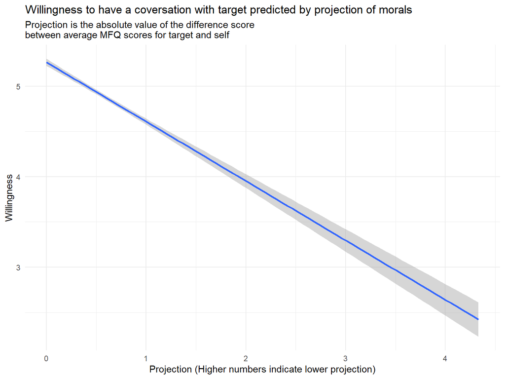

```r
#main effect of projection
ggplot(downstream_analysis, aes(proj_diff, WilltoDiscuss)) +
  geom_smooth(method = "lm") +
  theme_minimal() +
  labs(title = "Willingness to have a coversation with target predicted by projection of morals",
       subtitle = "Projection is the absolute value of the difference score \nbetween average MFQ scores for target and self",
       x = "Projection (Higher numbers indicate lower projection)",
       y = "Willingness")
```

As counter projection increased, willingness to have a conversation with the target decreased.

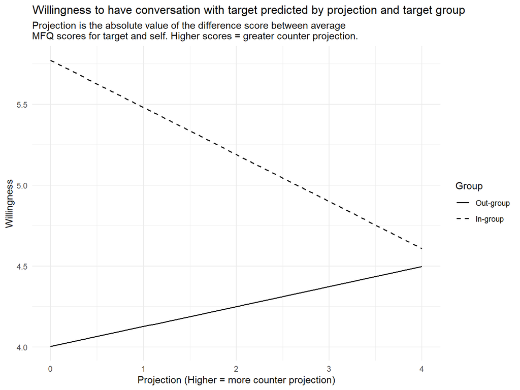

```r
discuss_overall_2way_group <- effect(term = "proj_diff:inoutgroup_effects",
                           xlevels = list(inoutgroup_effects = c(-.5,.5)),
                           mod = discuss_overall)

discuss_overall_2way_group <- as.data.frame(discuss_overall_2way_group)

discuss_overall_2way_group$group <- as.factor(discuss_overall_2way_group$inoutgroup_effects)

ggplot(discuss_overall_2way_group, aes(proj_diff, fit, group = group, color = group)) +
 geom_smooth(method = "lm", se = FALSE, size = .7, colour = "black",
              aes(linetype = group)) +
  theme_minimal() +
  scale_linetype_manual("Group", breaks = c(-.5, .5),
                       labels = c("Out-group", "In-group"),
                       values = c("solid",
                                   "dashed")) +
  labs(title = "Willingness to have conversation with target predicted by projection and target group",
       subtitle = "Projection is the absolute value of the difference score between average \nMFQ scores for target and self. Higher scores = greater counter projection.",
       x = "Projection (Higher = more counter projection)",
       y = "Willingness")
```

Willingness to have a conversation increases for people in the out-group as counter projection increases, while it decreases for the in-group as counter projection occurs. One possible explanation may be that people are willing to have a conversation with their out-group who they see as morally different in order to change them, while people in their in-group who have opposite morals might be more difficult (since they seemingly chose not to have some of the morals the in-group generally seems to share).

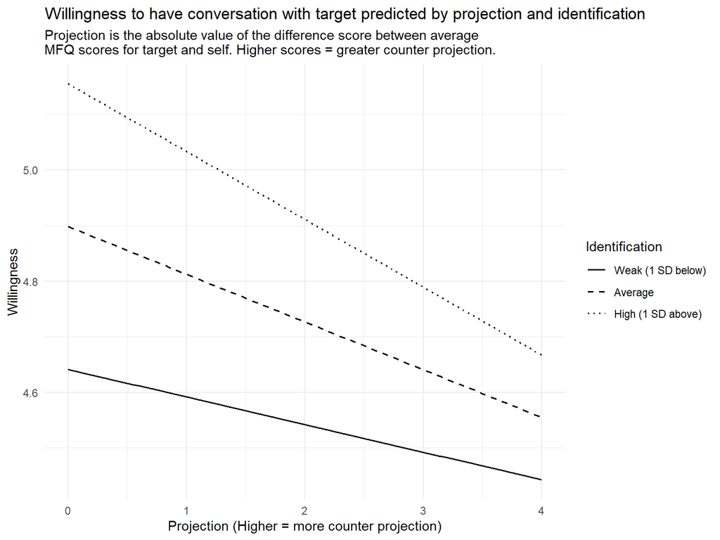

```r
discuss_overall_2way_ident <- effect(term = "proj_diff:ident_c",
                           xlevels = list(ident_c = c(-1.78, 0, 1.78)),
                           mod = discuss_overall)

discuss_overall_2way_ident <- as.data.frame(discuss_overall_2way_ident)

discuss_overall_2way_ident$Identification <- as.factor(discuss_overall_2way_ident$ident_c)

ggplot(discuss_overall_2way_ident, aes(proj_diff, fit, group = Identification, color = Identification)) +
 geom_smooth(method = "lm", se = FALSE, size = .7, colour = "black",
              aes(linetype = Identification)) +
  theme_minimal() +
  scale_linetype_manual("Identification", breaks = c(-1.78, 0, 1.78),
                       labels = c("Weak (1 SD below)",
                                  "Average",
                                  "High (1 SD above)"),
                       values = c("solid",
                                  "dashed",
                                  "dotted")) +
  labs(title = "Willingness to have conversation with target predicted by projection and identification",
       subtitle = "Projection is the absolute value of the difference score between average \nMFQ scores for target and self. Higher scores = greater counter projection.",
       x = "Projection (Higher = more counter projection)",
       y = "Willingness")
```

Willingness to have a conversation starts highest for all levels of identification when they project and this decreases as counter projection increases. However, as can be seen in the plot, the decrease in willingness to discuss as counter projection increases is steepest in higher identifiers, followed by average identifiers.

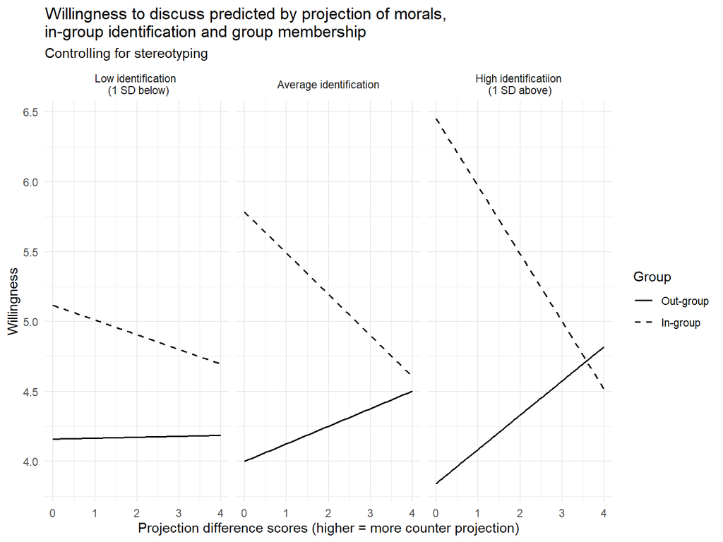

```r
discuss_overall_3way <- effect(term = "proj_diff:inoutgroup_effects:ident_c",
                           xlevels = list(ident_c = c(-1.78, 0, 1.78),
                                         inoutgroup_effects = c(-.5,.5)),
                           mod = discuss_overall)

discuss_overall_3way<- as.data.frame(discuss_overall_3way)

discuss_overall_3way$Group <- as.factor(discuss_overall_3way$inoutgroup_effects)
discuss_overall_3way$Identification <- as.factor(discuss_overall_3way$ident_c)

ident_label <- c("-1.78" = "Low identification \n (1 SD below)",
                 "0" = "Average identification",
                 "1.78" = "High identificatiion \n(1 SD above)")

ggplot(discuss_overall_3way, aes(proj_diff,
                             fit,
                             group = Group,
                             color = Group)) +
  geom_smooth(method = "lm", se = FALSE, size = .7, colour = "black",
              aes(linetype = Group)) +
  facet_wrap(~Identification, labeller =
               labeller(Identification = ident_label)) +
  scale_linetype_manual("Group", breaks = c(-.5, .5),
                       labels = c("Out-group", "In-group"),
                       values = c("solid",
                                   "dashed")) +
  theme_minimal() +
  labs(title = "Willingness to discuss predicted by projection of morals, \nin-group identification and group membership",
       subtitle = "Controlling for stereotyping",
       x = "Projection difference scores (higher = more counter projection)",
       y = "Willingness")
```

Willingness to have a conversation increases the most for out-group targets as counter projection increases and in-group identification increases (weird…). In contrast, willingness to have a conversation with in-group targets decrease as both in-group identification and counter projection increase.

### Binding model output

```r
discuss_bind <- lm(WilltoDiscuss ~ proj_bind_diff*stereo_bind_diff*inoutgroup_effects*ident_c, mfq_binding_diff)
summary(discuss_bind)
```

```
##
## Call:
## lm(formula = WilltoDiscuss ~ proj_bind_diff * stereo_bind_diff *
##     inoutgroup_effects * ident_c, data = mfq_binding_diff)
##
## Residuals:
##     Min      1Q  Median      3Q     Max
## -4.8811 -1.0349  0.2295  1.0608  3.3868
##
## Coefficients:
##                                                             Estimate Std. Error
## (Intercept)                                                 4.992709   0.037290
## proj_bind_diff                                             -0.194038   0.040442
## stereo_bind_diff                                            0.016543   0.042366
## inoutgroup_effects                                          2.121271   0.074579
## ident_c                                                     0.009517   0.022272
## proj_bind_diff:stereo_bind_diff                             0.003772   0.036562
## proj_bind_diff:inoutgroup_effects                          -0.241324   0.080884
## stereo_bind_diff:inoutgroup_effects                        -0.641452   0.084732
## proj_bind_diff:ident_c                                      0.059338   0.019355
## stereo_bind_diff:ident_c                                    0.119775   0.024109
## inoutgroup_effects:ident_c                                  0.027979   0.044543
## proj_bind_diff:stereo_bind_diff:inoutgroup_effects          0.188985   0.073124
## proj_bind_diff:stereo_bind_diff:ident_c                    -0.049685   0.016036
## proj_bind_diff:inoutgroup_effects:ident_c                   0.212977   0.038711
## stereo_bind_diff:inoutgroup_effects:ident_c                 0.310620   0.048219
## proj_bind_diff:stereo_bind_diff:inoutgroup_effects:ident_c -0.150533   0.032072
##                                                            t value
## (Intercept)                                                133.890
## proj_bind_diff                                              -4.798
## stereo_bind_diff                                             0.390
## inoutgroup_effects                                          28.443
## ident_c                                                      0.427
## proj_bind_diff:stereo_bind_diff                              0.103
## proj_bind_diff:inoutgroup_effects                           -2.984
## stereo_bind_diff:inoutgroup_effects                         -7.570
## proj_bind_diff:ident_c                                       3.066
## stereo_bind_diff:ident_c                                     4.968
## inoutgroup_effects:ident_c                                   0.628
## proj_bind_diff:stereo_bind_diff:inoutgroup_effects           2.584
```

[output cut: 29 more lines]

```
## stereo_bind_diff:inoutgroup_effects                        ***
## proj_bind_diff:ident_c                                     **
## stereo_bind_diff:ident_c                                   ***
## inoutgroup_effects:ident_c
## proj_bind_diff:stereo_bind_diff:inoutgroup_effects         **
## proj_bind_diff:stereo_bind_diff:ident_c                    **
## proj_bind_diff:inoutgroup_effects:ident_c                  ***
## stereo_bind_diff:inoutgroup_effects:ident_c                ***
## proj_bind_diff:stereo_bind_diff:inoutgroup_effects:ident_c ***
## ---
## Signif. codes:  0 '***' 0.001 '**' 0.01 '*' 0.05 '.' 0.1 ' ' 1
##
## Residual standard error: 1.685 on 11926 degrees of freedom
## Multiple R-squared:  0.2297, Adjusted R-squared:  0.2287
## F-statistic:   237 on 15 and 11926 DF,  p-value: < 0.00000000000000022
```

### Binding plots

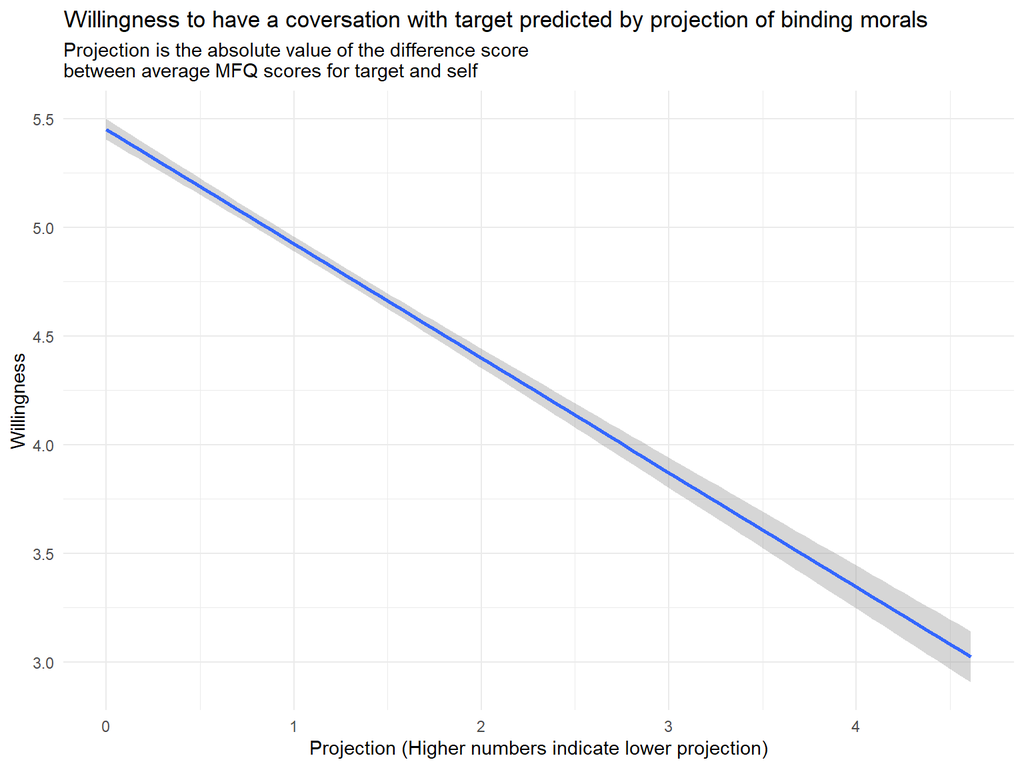

```r
#main effect of projection
ggplot(mfq_binding_diff, aes(proj_bind_diff, WilltoDiscuss)) +
  geom_smooth(method = "lm") +
  theme_minimal() +
  labs(title = "Willingness to have a coversation with target predicted by projection of binding morals",
       subtitle = "Projection is the absolute value of the difference score \nbetween average MFQ scores for target and self",
       x = "Projection (Higher numbers indicate lower projection)",
       y = "Willingness")
```